# PCS Documentation

March 09, 2022

# 1 Domain problem formulation

What is the real-world question? This could be hypothesis-driven or discovery-based.

> This should be very high level, providing the big picture behind the study. Often this takes the form of a pre-existing hypothesis (e.g., individuals with a specific genetic mutation are more likely to have a given characteristic) or more open-ended discovery (e.g., identify mutations that are related to a given characteristic).

Why is this question interesting and important? What are the implications of better understanding this data?

> Try to incentive this study for those coming from a variety of backgrounds and levels of scientific understanding. Perhaps mention how previous related work made an impact in the field.

Briefly describe any background information necessary to understand this problem.

> This should provide readers some intuition for the scientific problem. This section should be a short high-level summary. For additional details, one can refer readers to introductory material, tutorials, and/or review papers.

Briefly describe how this question can be answered in the context of a model or analysis.

Outline the rest of the report/analysis.

# 2 Data

What is the data under investigation? Provide a brief overview/description of the data.

Describe how your data connects to the domain problem.

## 2.1 Data Collection

How was the data collected or generated (including details on the experimental design)? Be as transparent as possible so that conclusions made from this data are not misinterpreted down the road.

Describe any limitations when using the data to answer the domain problem of interest.

> While the previous section lays out the entire collection process, here it is important to highlight any limitations as these may not be obvious to those from other fields. This includes any personal judgement calls made in the data collection process.

Where is the data stored, and how can it be accessed by others (if applicable)?

## 2.2 Data Splitting

Decide on the proportion of data in each split.

Decide on the “how” to split the data (e.g., random sampling, stratified sampling, etc.), and explain why this is a reasonable way to split the data.

> Here, we refer to splitting data into training, validation, and test portions. Generally, one fits select models (including any necessary tuning procedures) on the training data and assesses prediction accuracy on the validation data to compare models against one another. **The test data should only be utilized once after all data analysis is completed.**

> Note that *how* the data splitting is performed can greatly affect the results. This is because data often have underlying inherent structures and relationships (e.g., longitudinal information, related individuals, ethnicity, varying hospitals, etc.) that should be preserved when splitting. As a concrete example, if the data under study comes from patients across four hospitals, it is often advisable to perform the data splitting by hospital so that the training set is composed of all patients from hospitals A and B, the validation set is composed of all patients from hospital C, and the test set is composed of all patients from hospital D. By splitting the data in this way, the validation (or test) accuracy is a more accurate evaluation of how the fitted model will perform on a completely new batch of data in the future. Ultimately, the goal of the data splitting scheme is to mimic the process of obtaining new **future data**.

Split the data into a training, validation, and test set.

```r
data_split <- split_data(X = X, y = y, stratified_by = y,
                         train_prop = params$train_prop,
                         valid_prop = params$valid_prop,
                         test_prop = params$test_prop)
Xtrain <- data_split$X$train
Xvalid <- data_split$X$validate
Xtest <- data_split$X$test
ytrain <- data_split$y$train
yvalid <- data_split$y$validate
ytest <- data_split$y$test
```

Provide summary statistics and/or figures of the three data sets to illustrate how similar (or different) they are.

> This step is important as it can highlight any concerns with your chosen splitting rule. For instance, under the classification setting, the distribution of categories should be similar across the three data sets.

### 2.2.1 Data Splitting Overview

#### X Data Split

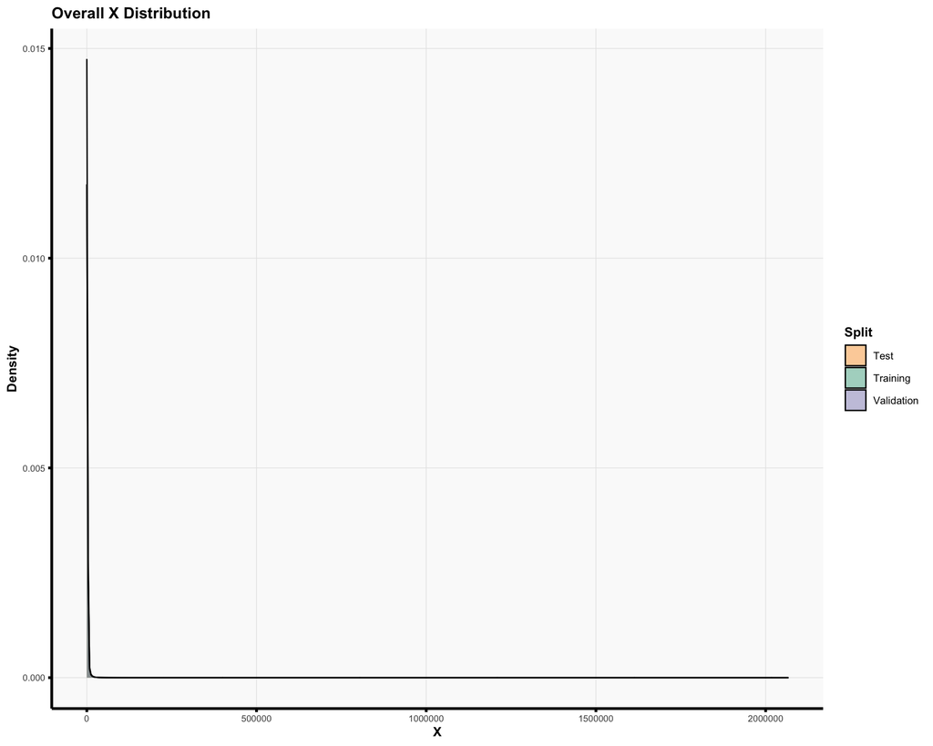

```r
plot_data_split(Xtrain, Xvalid, Xtest,
                xlab = "X", title = "Overall X Distribution")
```

#### Y Data Split

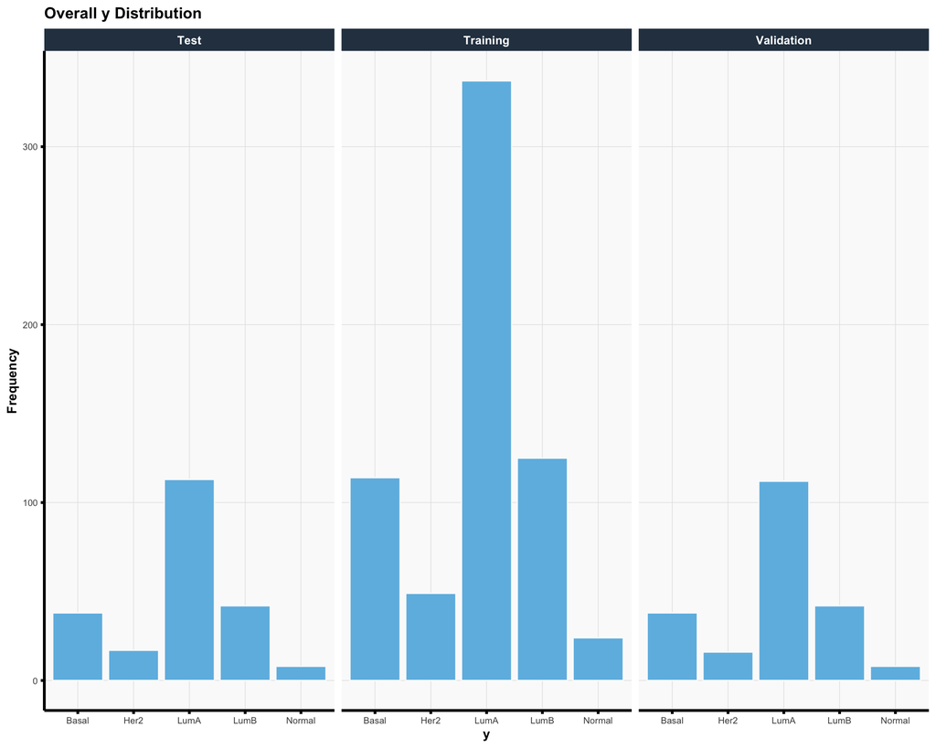

```r
plot_data_split(ytrain, yvalid, ytest,
                xlab = "y", title = "Overall y Distribution")
```

## 2.3 Data Cleaning and Preprocessing

What steps were taken to clean the data? More importantly, why was the data cleaned in this way?

> Data cleaning can be very problem and domain dependent. Be sure to specify which approaches are common in the field and why. Where appropriate, highlight any steps that were judgement calls necessary to continue the analysis.

Discuss all inconsistencies, problems, oddities in the data (e.g., missing data, errors in data, outliers, etc.).

Record your preprocessing steps in a way such that if someone else were to reproduce your analysis, they could easily replicate and understand your steps.

It can be helpful to include relevant plots that explain/justify the choices that were made when cleaning the data.

If more than one preprocessing pipeline is reasonable, examine the impacts of these alternative preprocessing pipelines on the final data results.

> There are often multiple, standard preprocessing options that should be tested to assess stability of results. Any judgement calls mentioned above should also be compared with alternative choices where possible.

Again, be as transparent as possible. This allows others to make their own educated decisions on how best to preprocess the data.

```r
## DO DATA CLEANING / PRE-PROCESSING HERE
Xtrain <- log(Xtrain + 1) %>%
  remove_constant_cols(verbose = 1) %>%
  remove_duplicate_cols(verbose = 1) %>%
  filter_cols_by_var(max_p = 1000)
```

```
#> Removed 296 features with constant values
#> Removed 5 features that are duplicated
```

```r
Xvalid <- log(Xvalid + 1)[, colnames(Xtrain)]
Xtest <- log(Xtest + 1)[, colnames(Xtrain)]
```

## 2.4 Data Exploration

The main goal of this section is to give the reader a feel for what the data “looks like” at a basic level.

Provide plots that summarize the data and perhaps even plots that convey some smaller findings which ultimately motivate the main findings.

Provide additional plots representing remaining oddities after pre-processing if applicable.

Add summary statistics in accompanying tables (or in figures) for quick comparisons.

### 2.4.1 Data Overview

```
#> Number of features: 1000
#> Number of training samples: 649
#> Number of validaiton samples: 216
#> Number of test samples: 218
```

```r
# summary of types of features in (X, y) data
get_data_types(X = Xtrain, y = ytrain)
```

|  | Factor | Numeric |
| --- | --- | --- |
| X | 0 | 1000 |
| y | 1 | 0 |

#### Summary Tables

```r
# broad array of summary statistics for features in training (X, y)
tab_ls <- get_data_summary(X = Xtrain, y = ytrain)
for (dtype in names(tab_ls)) {  # grouped by data type
  vthemes::subchunkify(tab_ls[[dtype]],
                       i = dtype, other_args = "results='asis'")
}
```

| Variable Name | # Missing | % Missing | Ordered Factor | # Unique Factors | Top Factor Counts |
| --- | --- | --- | --- | --- | --- |
| .y | 0 | 0.00 | False | 5 | Lum: 337, Lum: 125, Bas: 114, Her: 49 |

| Variable Name | # Missing | % Missing | Mean | SD | Minimum | Q1 | Median | Q3 | Maximum | Histogram |
| --- | --- | --- | --- | --- | --- | --- | --- | --- | --- | --- |
| NAT1 | 0 | 0.00 | 6.71 | 1.93 | 1.80 | 4.99 | 7.05 | 8.34 | 11.60 | ▂▆▆▇▁ |
| RP11.986E7.7 | 0 | 0.00 | 9.13 | 1.55 | 3.70 | 8.25 | 9.41 | 10.22 | 12.37 | ▁▂▅▇▂ |
| ABCA4 | 0 | 0.00 | 3.32 | 1.53 | 0.00 | 2.12 | 3.18 | 4.39 | 7.99 | ▃▇▇▃▁ |
| AOC1 | 0 | 0.00 | 2.61 | 1.47 | 0.00 | 1.66 | 2.42 | 3.26 | 9.15 | ▅▇▂▁▁ |
| ACADL | 0 | 0.00 | 1.72 | 1.45 | 0.00 | 0.57 | 1.40 | 2.60 | 7.13 | ▇▅▂▁▁ |
| ASIC2 | 0 | 0.00 | 1.39 | 1.50 | 0.00 | 0.33 | 0.84 | 2.01 | 6.99 | ▇▂▁▁▁ |
| ACTA1 | 0 | 0.00 | 2.79 | 1.67 | 0.00 | 1.48 | 2.49 | 3.89 | 10.42 | ▇▇▃▁▁ |
| ACTG2 | 0 | 0.00 | 5.58 | 1.62 | 0.58 | 4.55 | 5.40 | 6.62 | 11.27 | ▁▅▇▂▁ |
| ACTN2 | 0 | 0.00 | 1.90 | 1.62 | 0.00 | 0.68 | 1.41 | 2.60 | 9.50 | ▇▃▂▁▁ |
| ADCY1 | 0 | 0.00 | 5.94 | 1.55 | 2.47 | 4.83 | 5.83 | 6.91 | 10.65 | ▃▇▇▃▁ |

[output cut: 990 more lines]

#### X Distribution

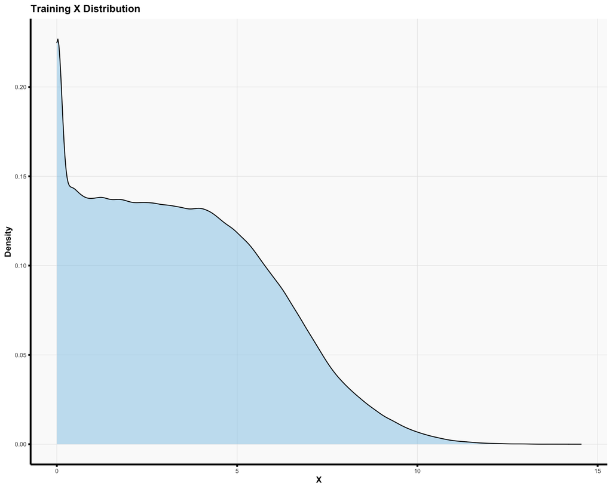

```r
# plot X distribution
plot_data_distribution(data = Xtrain,
                       xlab = "X", title = "Training X Distribution")
```

#### Y Distribution

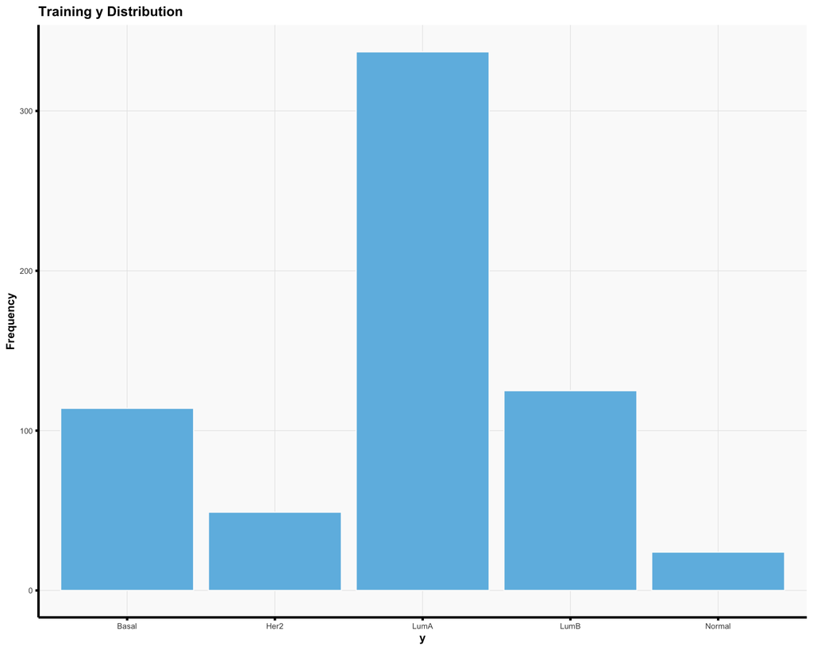

```r
# plot y distribution
plot_data_distribution(data = ytrain,
                       xlab = "y", title = "Training y Distribution")
```

#### Data Heatmap

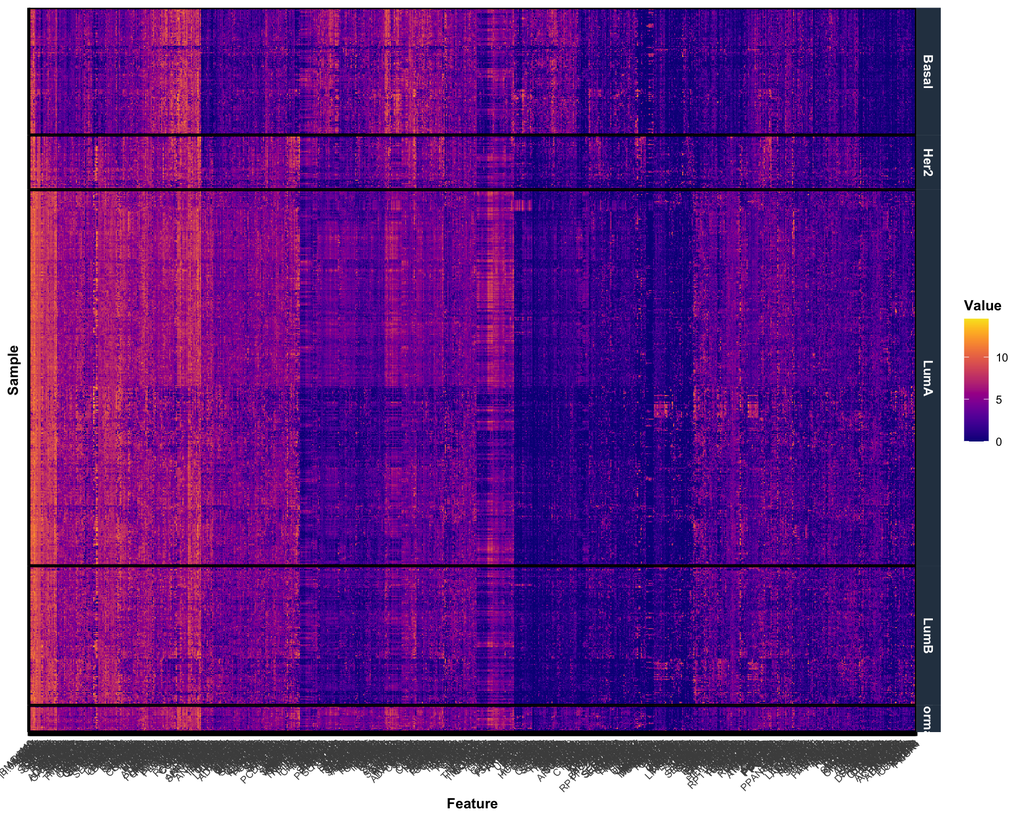

```r
# (clustered) heatmap of (X, y) data
plot_data_heatmap(X = Xtrain, y = ytrain, clust_rows = TRUE, clust_cols = TRUE,
                  show_ytext = FALSE, x_text_angle = TRUE)
```

#### Feature Correlation

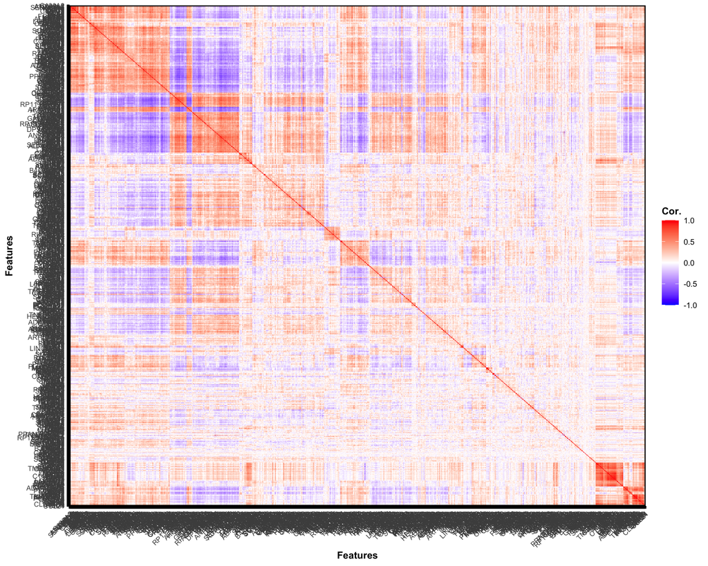

```r
# (clustered) correlation heatmap
plot_cor_heatmap(X = Xtrain, cor_type = "pearson", clust = TRUE,
                 x_text_angle = TRUE) +
  ggplot2::labs(x = "Features", y = "Features", fill = "Cor.")
```

#### Feature Pair Plots

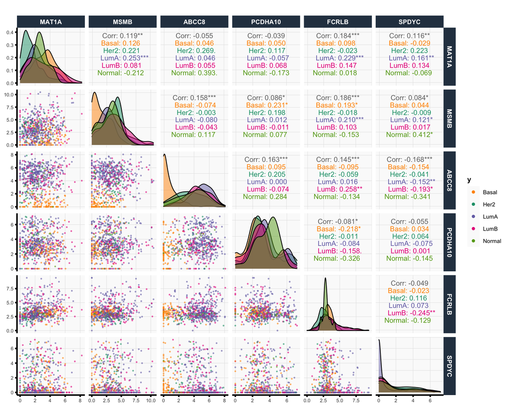

```r
# feature pair plot (for a subset of features)
keep_features <- sort(
  sample(1:ncol(Xtrain), min(ncol(Xtrain), 6), replace = FALSE)
)
plot_pairs(data = Xtrain, columns = keep_features,
           color = ytrain, color_label = "y")
```

#### Marginal Associations

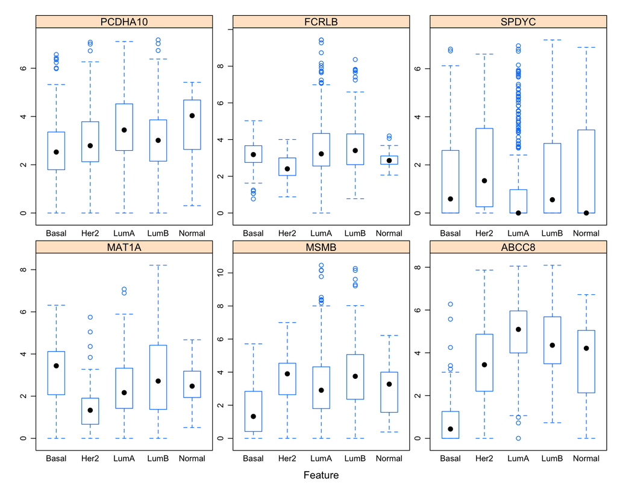

```r
# marginal association plots (for a subset of features)
caret::featurePlot(x = Xtrain[, keep_features],
                   y = ytrain,
                   plot = if (is.factor(ytrain)) "box" else "scatter",
                   scales = list(x = list(relation = "free"),
                                 y = list(relation = "free")))
```

#### PCA

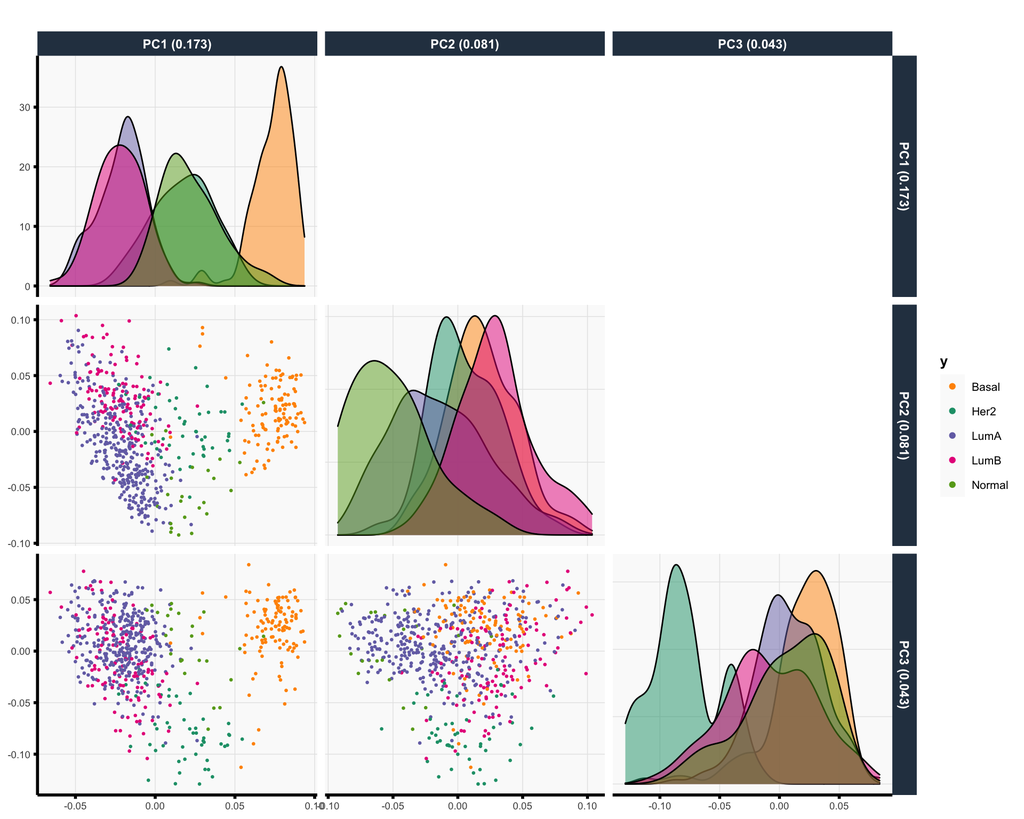

```r
# pca plot
plot_pca(X = Xtrain, npcs = 3, color = ytrain, color_label = "y",
         center = TRUE, scale = FALSE)$plot
```

# 3 Prediction Modeling

Discuss the prediction methods under consideration, and explain why these methods were chosen.

> There are an overwhelming number of methods available, but at least one should be a common approach acting as a baseline. This may not be optimal for the problem setting, but serves as a helpful comparison. Any “go-to” methods in this scientific domain should also be considered. Discuss why these are favored. For instance, is there a natural structure in the data that is better utilized in one approach vs another? Conversely, mention if there are approaches that are typically avoided in these problems. The limitations discussed previously can also help to guide these modeling decisions.

> Furthermore, think back to the big picture. If interpretability is important, methods favoring sparser, simpler models may be preferred (e.g., sparse regression or tree-based procedures). If prediction is the sole goal, more complex models may be appropriate.

> If computing time is a burden and rules out methods with high potential, this should be highlighted for future reference as scalability and/or computing resources improve.

Discuss the accuracy metrics under consideration, and explain why these metrics were chosen.

> These accuracy metrics should clearly support the main goal of the study. There are often multiple ways to quantify accuracy (e.g., RMSE, $R^2$, correlation, AUROC, AUPRC, classification accuracy). Often, comparing across several metrics provides an additional stability check and a more holistic picture of the model performance.

## 3.1 Prediction check

Carry out the prediction pipeline, outlined above.

1. Fit prediction methods on training data. (Note: this includes any parameter tuning which may require further data splitting (e.g., k-fold cross-validation) **within the training data**.)
2. Evaluate prediction methods on validation data.
3. Compare results, and filter out poor models.

```r
## IF USING TIDYMODELS BACKEND, CHOOSE METHODS AND TRAINING CONTROLS HERE
cv_options <- list(nfolds = 5,
                   foldids = NULL,
                   metric = "accuracy")

model_list <- list(
  rand_forest = list(.tune_params = list(mtry = round(seq(sqrt(ncol(Xtrain)),
                                                          ncol(Xtrain) / 3,
                                                          length.out = 3))),
                     engine = list(engine = "ranger",
                                   importance = "impurity")),
  boost_tree = list(engine = "xgboost")
)
```

```r
# fit/train models
fit_results <- fit_models(Xtrain = Xtrain, ytrain = ytrain,
                          model_list = model_list, cv_options = cv_options,
                          use = params$modeling_pkg)
```

```
#> [00:59:38] WARNING: amalgamation/../src/learner.cc:1115: Starting in XGBoost 1.3.0, the default evaluation metric used with the objective 'multi:softprob' was changed from 'merror' to 'mlogloss'. Explicitly set eval_metric if you'd like to restore the old behavior.
```

```r
# make prediction on validation set
pred_results <- predict_models(fit_list = fit_results, Xtest = Xvalid)

# evaluate predictions on validation set
eval_results <- evaluate_models(pred_df = pred_results, ytest = yvalid)

# collect feature importance metrics from model fits
imp_results <- interpret_models(fit_list = fit_results)
```

### Fit Summary

#### rand_forest

```
#> Fitting time taken: 2.71834721565247 min
#>
#> =====================================================
#> ================ Tuned Model Summary ================
#> =====================================================
#>
#> ══ Workflow [trained] ═══════════════════════════════════════════════════════════════════════════════════════════════════════════════════════════════════════════════════════════════════════════════════════════════════════════════════════════════════════════════════════════════════════════════════…
#> Preprocessor: Formula
#> Model: rand_forest()
#>
#> ── Preprocessor ─────────────────────────────────────────────────────────────────────────────────────────────────────────────────────────────────────────────────────────────────────────────────────────────────────────────────────────────────────────────────────────────────────────────────────────…
#> .y ~ .
#>
#> ── Model ────────────────────────────────────────────────────────────────────────────────────────────────────────────────────────────────────────────────────────────────────────────────────────────────────────────────────────────────────────────────────────────────────────────────────────────────…
#> Ranger result
#>
#> Call:
#>  ranger::ranger(x = maybe_data_frame(x), y = y, mtry = min_cols(~182,      x), importance = ~"impurity", num.threads = 1, verbose = FALSE,      seed = sample.int(10^5, 1), probability = TRUE)
#>
#> Type:                             Probability estimation
#> Number of trees:                  500
#> Sample size:                      649
#> Number of independent variables:  1000
#> Mtry:                             182
#> Target node size:                 10
#> Variable importance mode:         impurity
#> Splitrule:                        gini
#> OOB prediction error (Brier s.):  0.1597182
#>
#>
#> ======================================================
#> ==== Summary of CV Fit for Tuning Hyperparameters ====
#> ======================================================
#>
#> # Tuning results
#> # 5-fold cross-validation
#> # A tibble: 5 × 4
#>   splits            id    .metrics         .notes
#>   <list>            <chr> <list>           <list>
#> 1 <split [519/130]> Fold1 <tibble [6 × 5]> <tibble [0 × 1]>
#> 2 <split [519/130]> Fold2 <tibble [6 × 5]> <tibble [0 × 1]>
#> 3 <split [519/130]> Fold3 <tibble [6 × 5]> <tibble [0 × 1]>
#> 4 <split [519/130]> Fold4 <tibble [6 × 5]> <tibble [0 × 1]>
#> 5 <split [520/129]> Fold5 <tibble [6 × 5]> <tibble [0 × 1]>
#>
#> # Metrics Summary
#> # A tibble: 6 × 9
#>    mtry .metric   Mean      SD Fold1 Fold2 Fold3 Fold4 Fold5
#>   <dbl> <chr>    <dbl>   <dbl> <dbl> <dbl> <dbl> <dbl> <dbl>
#> 1    32 accuracy 0.815 0.0343  0.823 0.808 0.854 0.762 0.829
#> 2   182 accuracy 0.823 0.0455  0.769 0.823 0.892 0.8   0.829
#> 3   333 accuracy 0.823 0.0380  0.792 0.815 0.885 0.792 0.829
#> 4    32 roc_auc  0.959 0.00477 0.957 0.966 0.959 0.960 0.953
#> 5   182 roc_auc  0.962 0.00688 0.956 0.969 0.964 0.967 0.953
#> 6   333 roc_auc  0.958 0.00851 0.945 0.967 0.961 0.962 0.954
```

#### boost_tree

```
#> Fitting time taken: 0.123900850613912 min
#>
#> =====================================================
#> =================== Model Summary ===================
#> =====================================================
#>
#> ══ Workflow [trained] ═══════════════════════════════════════════════════════════════════════════════════════════════════════════════════════════════════════════════════════════════════════════════════════════════════════════════════════════════════════════════════════════════════════════════════…
#> Preprocessor: Formula
#> Model: boost_tree()
#>
#> ── Preprocessor ─────────────────────────────────────────────────────────────────────────────────────────────────────────────────────────────────────────────────────────────────────────────────────────────────────────────────────────────────────────────────────────────────────────────────────────…
#> .y ~ .
#>
#> ── Model ────────────────────────────────────────────────────────────────────────────────────────────────────────────────────────────────────────────────────────────────────────────────────────────────────────────────────────────────────────────────────────────────────────────────────────────────…
#> ##### xgb.Booster
#> raw: 137.4 Kb
#> call:
#>   xgboost::xgb.train(params = list(eta = 0.3, max_depth = 6, gamma = 0,
#>     colsample_bytree = 1, colsample_bynode = 1, min_child_weight = 1,
#>     subsample = 1, objective = "multi:softprob"), data = x$data,
#>     nrounds = 15, watchlist = x$watchlist, verbose = 0, num_class = 5L,
#>     nthread = 1)
#> params (as set within xgb.train):
#>   eta = "0.3", max_depth = "6", gamma = "0", colsample_bytree = "1", colsample_bynode = "1", min_child_weight = "1", subsample = "1", objective = "multi:softprob", num_class = "5", nthread = "1", validate_parameters = "TRUE"
#> xgb.attributes:
#>   niter
#> callbacks:
#>   cb.evaluation.log()
#> # of features: 1000
#> niter: 15
#> nfeatures : 1000
#> evaluation_log:
#>     iter training_mlogloss
#>        1          1.046141
#>        2          0.749682
#> ---
#>       14          0.045483
#>       15          0.038782
```

### Prediction Results

|  | boost_tree | rand_forest |
| --- | --- | --- |
| sens | 0.75 | 0.73 |
| spec | 0.96 | 0.95 |
| f_meas | 0.76 | 0.77 |
| kap | 0.80 | 0.79 |
| accuracy | 0.88 | 0.87 |
| bal_accuracy | 0.85 | 0.84 |
| ppv | 0.82 | 0.90 |
| npv | 0.97 | 0.97 |
| roc_auc | 0.97 | 0.98 |
| pr_auc | 0.85 | 0.91 |

[output cut: 1 more lines]

### Confusion Tables

boost_tree Confusion Matrix on Validation Set

| Prediction | Truth Basal | Truth Her2 | Truth LumA | Truth LumB | Truth Normal |
| --- | --- | --- | --- | --- | --- |
| Basal | 37 | 0 | 0 | 0 | 3 |
| Her2 | 1 | 14 | 2 | 0 | 3 |
| LumA | 0 | 1 | 108 | 14 | 0 |
| LumB | 0 | 1 | 1 | 28 | 0 |
| Normal | 0 | 0 | 1 | 0 | 2 |

rand_forest Confusion Matrix on Validation Set

| Prediction | Truth Basal | Truth Her2 | Truth LumA | Truth LumB | Truth Normal |
| --- | --- | --- | --- | --- | --- |
| Basal | 38 | 0 | 0 | 0 | 3 |
| Her2 | 0 | 13 | 1 | 0 | 1 |
| LumA | 0 | 1 | 109 | 16 | 2 |
| LumB | 0 | 2 | 2 | 26 | 0 |
| Normal | 0 | 0 | 0 | 0 | 2 |

### ROC Plot

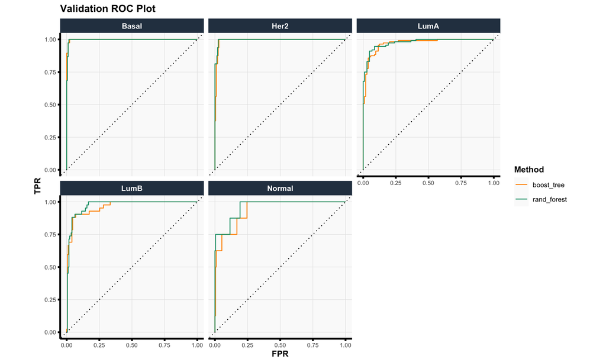

### PR Plot

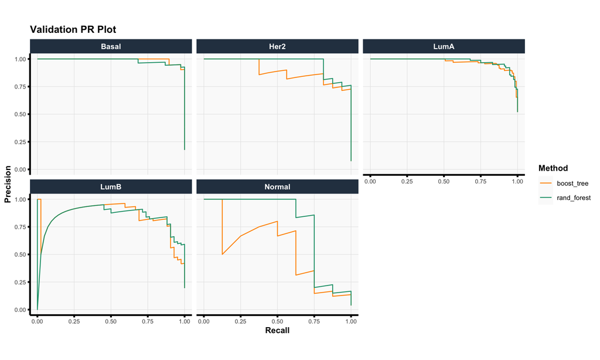

## 3.2 Stability check

Taking the prediction methods that pass the prediction check, perform a stability analysis.

> One way to assess a model’s stability is to assess changes in model’s validation accuracy based on appropriate data perturbations of the training data. However, this stability analysis is heavily dependent on the problem at hand and should be tailored to assess the stability of metrics that are relevant to the domain problem.
1. Specify and justify the appropriate data perturbation(s).

   > As when determining an appropriate splitting rule, the perturbation scheme should incorporate any known data structure. For instance, if using a bootstrap approach with structured data, stratified sampling may be more appropriate to better mimic the process of obtaining a new batch of data in the future.
2. Re-fit the prediction methods on these perturbed data sets.
3. Evaluate prediction methods on validation data.
4. Assess stability across the data perturbations as well as across the various methods.
5. Filter out poor models where necessary and interpret stability results.

   > Methods with highly variable accuracy should be discarded. In addition, take note if any set of perturbations resulted in uniformly poor accuracy across methods. This could indicate an underlying issue with the perturbation scheme.

```r
n_reps <- params$n_data_perturbations

# p <- progressr::progressor(steps = n_reps)
# future::plan(multisession, workers = min(n_reps, parallel::detectCores() - 1))
bootstrap_model_results <- future.apply::future_replicate(
  n = n_reps,
  expr = {
    bootstrap <- sample(1:nrow(Xtrain), nrow(Xtrain), replace = TRUE)
    Xtrain_b <- Xtrain[bootstrap, ]
    ytrain_b <- ytrain[bootstrap]

    # fit/train models on bootstrap data
    fit_results_b <- fit_models(Xtrain = Xtrain_b, ytrain = ytrain_b,
                                model_list = model_list, cv_options = cv_options,
                                use = params$modeling_pkg)

    # make prediction on validation set
    pred_results_b <- predict_models(fit_list = fit_results_b, Xtest = Xvalid)

    # evaluate predictions on validation set
    eval_results_b <- evaluate_models(pred_df = pred_results_b, ytest = yvalid)

    # collect feature importance metrics from model fits
    imp_results_b <- interpret_models(fit_list = fit_results_b)

    return(list(# fit = fit_results_b,  # uncomment if need bootstrap fits; can be memory intensive
                predictions = pred_results_b,
                eval_metrics = eval_results_b,
                importances = imp_results_b))
  },
  simplify = FALSE
)
```

```
#> [01:02:12] WARNING: amalgamation/../src/learner.cc:1115: Starting in XGBoost 1.3.0, the default evaluation metric used with the objective 'multi:softprob' was changed from 'merror' to 'mlogloss'. Explicitly set eval_metric if you'd like to restore the old behavior.
#> [01:04:23] WARNING: amalgamation/../src/learner.cc:1115: Starting in XGBoost 1.3.0, the default evaluation metric used with the objective 'multi:softprob' was changed from 'merror' to 'mlogloss'. Explicitly set eval_metric if you'd like to restore the old behavior.
```

```r
bootstrap_model_errs <- purrr::map_dfr(bootstrap_model_results,
                                       ~.x$eval_metrics$metrics,
                                       .id = "bootstrap_id")
bootstrap_model_preds <- purrr::map(bootstrap_model_results, "predictions")
bootstrap_model_imps <- purrr::map_dfr(bootstrap_model_results, "importances",
                                       .id = "bootstrap_id")

# summarize bootstrap model error metrics
bootstrap_model_errs_summary <- bootstrap_model_errs %>%
  tidyr::pivot_longer(cols = c(-bootstrap_id, -metric),
                      names_to = "Method", values_to = "Value") %>%
  dplyr::rename(Metric = metric) %>%
  dplyr::group_by(Method, Metric) %>%
  dplyr::summarise(Mean = mean(Value), SD = sd(Value), .groups = "drop") %>%
  tidyr::pivot_longer(cols = c(Mean, SD),
                      values_to = "Value", names_to = "Statistic") %>%
  tidyr::pivot_wider(names_from = "Method", values_from = "Value") %>%
  dplyr::arrange(Metric, Statistic)
```

### Table

```r
# table of accuracy metrics
vthemes::pretty_table(
  bootstrap_model_errs_summary,
  digits = 2, sigfig = FALSE, rownames = FALSE,
  caption = "Validation Prediction Accuracies Over Bootstrapped Training Fits",
  html_options = list(
    extensions = "RowGroup",
    options = list(
      dom = "t",
      pageLength = nrow(bootstrap_model_errs_summary),
      scrollY = "500px",
      rowGroup = list(dataSrc = 0),
      columnDefs = list(list(className = "dt-center", targets = "_all"),
                        list(visible = FALSE, targets = 0),
                        list(title = "Metric", targets = 1))
    )
  )
)
```

| Metric | Statistic | boost_tree | rand_forest |
| --- | --- | --- | --- |
| accuracy | Mean | 0.83 | 0.85 |
| accuracy | SD | 0.01 | 0.05 |
| bal_accuracy | Mean | 0.81 | 0.82 |
| bal_accuracy | SD | 0.03 | 0.05 |
| f_meas | Mean | 0.77 | 0.72 |
| f_meas | SD | 0.04 | 0.08 |
| kap | Mean | 0.73 | 0.75 |
| kap | SD | 0.02 | 0.08 |
| mn_log_loss | Mean | 0.42 | 0.45 |
| mn_log_loss | SD | 0.01 | 0.04 |

[output cut: 12 more lines]

### Plot

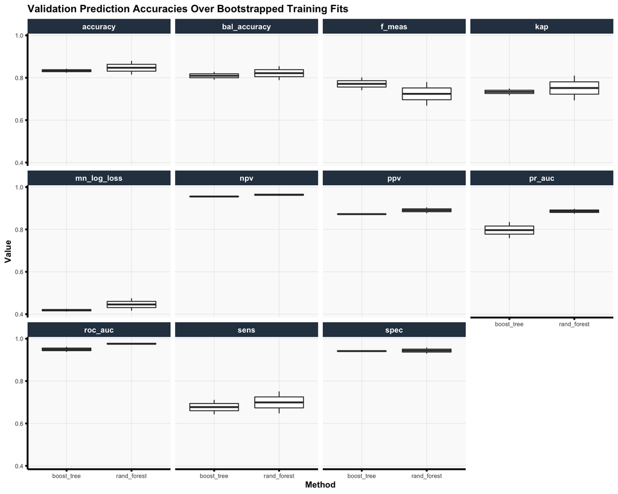

```r
# boxplots
bootstrap_model_errs %>%
  tidyr::pivot_longer(cols = c(-bootstrap_id, -metric),
                      names_to = "Method", values_to = "Value") %>%
  plot_boxplot(x_str = "Method", y_str = "Value") +
  ggplot2::facet_wrap(~ metric) +
  ggplot2::labs(title = "Validation Prediction Accuracies Over Bootstrapped Training Fits")
```

## 3.3 Interpretability

For the models that pass the prediction and stability checks, extract the important features in the predictive models that are stable across both data and model perturbations. Determining the importance of a feature can be method dependent.

### Full Model (without stability)

#### Table

```r
vthemes::pretty_table(imp_results, digits = 2, sigfig = FALSE,
                      caption = "Variable Importances")
```

|  | Method | Variable | Importance |
| --- | --- | --- | --- |
| 1 | rand_forest | MLPH | 28.13 |
| 2 | rand_forest | ESR1 | 27.78 |
| 3 | rand_forest | FOXA1 | 21.36 |
| 4 | rand_forest | PRR15 | 11.72 |
| 5 | rand_forest | AGR3 | 10.47 |
| 6 | rand_forest | SPDEF | 8.23 |
| 7 | rand_forest | C2orf40 | 7.38 |
| 8 | rand_forest | CT62 | 6.40 |
| 9 | rand_forest | CDCA7 | 5.78 |
| 10 | rand_forest | RP11.279F6.1 | 5.51 |

[output cut: 1412 more lines]

#### Plots

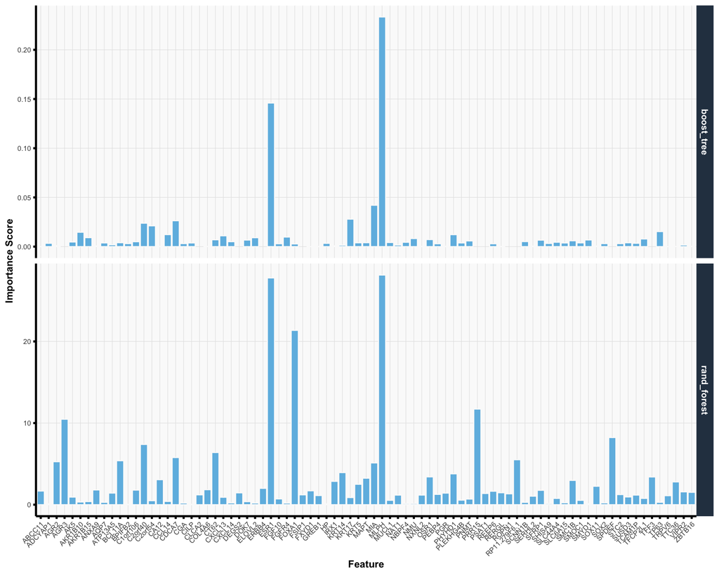

```r
plot_feature_importance(imp_results,
                        use_rankings = FALSE,
                        use_facets = TRUE,
                        interactive = FALSE)
```

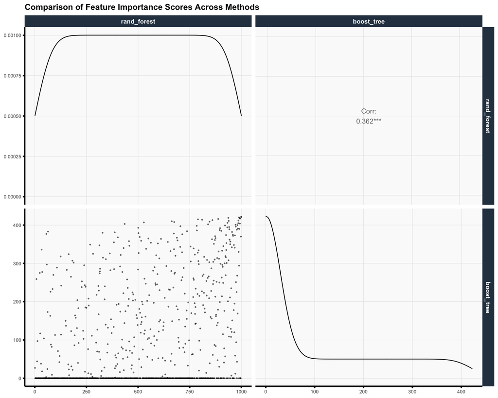

```r
plot_feature_importance_pair(imp_results,
                             use_rankings = TRUE,
                             interactive = FALSE)
```

### Bootstrapped Model (with stability)

#### Table

```r
bootstrap_model_imps_summary <- bootstrap_model_imps %>%
  dplyr::group_by(Method, Variable) %>%
  dplyr::summarise(`Mean Importance` = mean(Importance),
                   `Median Importance` = median(Importance),
                   `SD Importance` = sd(Importance),
                   `Min Importance` = min(Importance),
                   `Max Importance` = max(Importance),
                   .groups = "keep")
vthemes::pretty_table(
  bootstrap_model_imps_summary,
  digits = 2, sigfig = F,
  caption = "Summary of variable importances across bootstrapped models"
)
```

|  | Method | Variable | Mean Importance | Median Importance | SD Importance | Min Importance | Max Importance |
| --- | --- | --- | --- | --- | --- | --- | --- |
| 1 | boost_tree | A2ML1 | 0.00 | 0.00 | NA | 0.00 | 0.00 |
| 2 | boost_tree | ABCA4 | 0.00 | 0.00 | 0.00 | 0.00 | 0.00 |
| 3 | boost_tree | ABCC11 | 0.00 | 0.00 | NA | 0.00 | 0.00 |
| 4 | boost_tree | ABCC13 | 0.00 | 0.00 | NA | 0.00 | 0.00 |
| 5 | boost_tree | ABCC8 | 0.00 | 0.00 | NA | 0.00 | 0.00 |
| 6 | boost_tree | AC079776.2 | 0.00 | 0.00 | NA | 0.00 | 0.00 |
| 7 | boost_tree | ACADL | 0.00 | 0.00 | 0.00 | 0.00 | 0.00 |
| 8 | boost_tree | ACE2 | 0.00 | 0.00 | NA | 0.00 | 0.00 |
| 9 | boost_tree | ACSM1 | 0.00 | 0.00 | NA | 0.00 | 0.00 |
| 10 | boost_tree | ACTA1 | 0.00 | 0.00 | 0.00 | 0.00 | 0.00 |

[output cut: 1498 more lines]

#### Plots

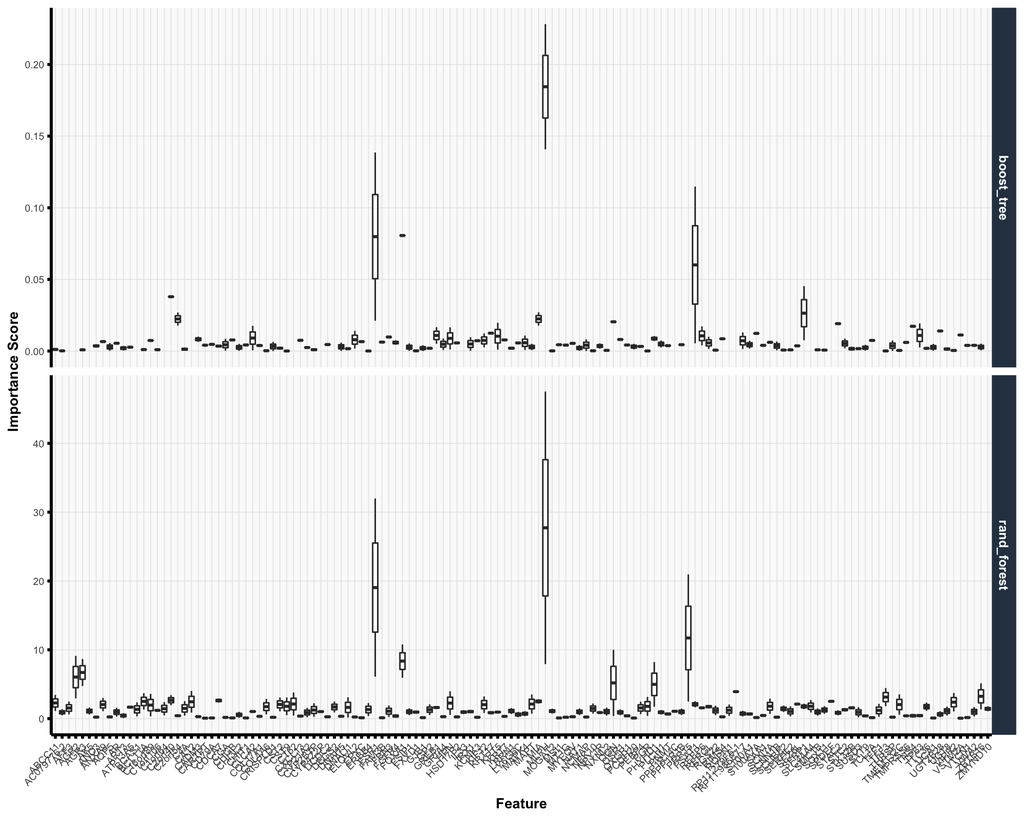

```r
plot_feature_importance_stability(bootstrap_model_imps,
                                  use_rankings = FALSE,
                                  use_facets = TRUE,
                                  interactive = FALSE)
```

# 4 Main Results

Interpret and summarize the prediction and stability results.

Evaluate pipeline on test data.

> Careful! Remember that **test data should only be touched once**. These results should not be used to make post-analysis modeling decisions. This is “double-dipping” and not an accurate measurement of out-of-sample accuracy.

```r
Xtrain_final <- dplyr::bind_rows(Xtrain, Xvalid)
ytrain_final <- c(ytrain, yvalid)

# fit/train models
fit_results_final <- fit_models(Xtrain = Xtrain_final, ytrain = ytrain_final,
                                model_list = model_list, cv_options = cv_options,
                                use = params$modeling_pkg)
```

```
#> [01:09:12] WARNING: amalgamation/../src/learner.cc:1115: Starting in XGBoost 1.3.0, the default evaluation metric used with the objective 'multi:softprob' was changed from 'merror' to 'mlogloss'. Explicitly set eval_metric if you'd like to restore the old behavior.
```

```r
# make prediction on test set
pred_results_final <- predict_models(fit_list = fit_results_final, Xtest = Xtest)

# evaluate predictions on test set
eval_results_final <- evaluate_models(pred_df = pred_results_final, ytest = ytest)

# collect feature importance metrics from model fits
imp_results_final <- interpret_models(fit_list = fit_results_final)
```

Summarize test set prediction and/or interpretability results.

### Fit Summary

#### rand_forest

```
#> Fitting time taken: 4.57439311742783 min
#>
#> =====================================================
#> ================ Tuned Model Summary ================
#> =====================================================
#>
#> ══ Workflow [trained] ═══════════════════════════════════════════════════════════════════════════════════════════════════════════════════════════════════════════════════════════════════════════════════════════════════════════════════════════════════════════════════════════════════════════════════…
#> Preprocessor: Formula
#> Model: rand_forest()
#>
#> ── Preprocessor ─────────────────────────────────────────────────────────────────────────────────────────────────────────────────────────────────────────────────────────────────────────────────────────────────────────────────────────────────────────────────────────────────────────────────────────…
#> .y ~ .
#>
#> ── Model ────────────────────────────────────────────────────────────────────────────────────────────────────────────────────────────────────────────────────────────────────────────────────────────────────────────────────────────────────────────────────────────────────────────────────────────────…
#> Ranger result
#>
#> Call:
#>  ranger::ranger(x = maybe_data_frame(x), y = y, mtry = min_cols(~333,      x), importance = ~"impurity", num.threads = 1, verbose = FALSE,      seed = sample.int(10^5, 1), probability = TRUE)
#>
#> Type:                             Probability estimation
#> Number of trees:                  500
#> Sample size:                      865
#> Number of independent variables:  1000
#> Mtry:                             333
#> Target node size:                 10
#> Variable importance mode:         impurity
#> Splitrule:                        gini
#> OOB prediction error (Brier s.):  0.1390541
#>
#>
#> ======================================================
#> ==== Summary of CV Fit for Tuning Hyperparameters ====
#> ======================================================
#>
#> # Tuning results
#> # 5-fold cross-validation
#> # A tibble: 5 × 4
#>   splits            id    .metrics         .notes
#>   <list>            <chr> <list>           <list>
#> 1 <split [692/173]> Fold1 <tibble [6 × 5]> <tibble [0 × 1]>
#> 2 <split [692/173]> Fold2 <tibble [6 × 5]> <tibble [0 × 1]>
#> 3 <split [692/173]> Fold3 <tibble [6 × 5]> <tibble [0 × 1]>
#> 4 <split [692/173]> Fold4 <tibble [6 × 5]> <tibble [0 × 1]>
#> 5 <split [692/173]> Fold5 <tibble [6 × 5]> <tibble [0 × 1]>
#>
#> # Metrics Summary
#> # A tibble: 6 × 9
#>    mtry .metric   Mean     SD Fold1 Fold2 Fold3 Fold4 Fold5
#>   <dbl> <chr>    <dbl>  <dbl> <dbl> <dbl> <dbl> <dbl> <dbl>
#> 1    32 accuracy 0.827 0.0142 0.832 0.815 0.809 0.844 0.832
#> 2   182 accuracy 0.846 0.0113 0.850 0.838 0.850 0.861 0.832
#> 3   333 accuracy 0.847 0.0176 0.850 0.832 0.867 0.861 0.827
#> 4    32 roc_auc  0.967 0.0126 0.969 0.978 0.979 0.953 0.954
#> 5   182 roc_auc  0.969 0.0151 0.975 0.982 0.981 0.951 0.953
#> 6   333 roc_auc  0.967 0.0169 0.973 0.981 0.982 0.946 0.951
```

#### boost_tree

```
#> Fitting time taken: 0.160102486610413 min
#>
#> =====================================================
#> =================== Model Summary ===================
#> =====================================================
#>
#> ══ Workflow [trained] ═══════════════════════════════════════════════════════════════════════════════════════════════════════════════════════════════════════════════════════════════════════════════════════════════════════════════════════════════════════════════════════════════════════════════════…
#> Preprocessor: Formula
#> Model: boost_tree()
#>
#> ── Preprocessor ─────────────────────────────────────────────────────────────────────────────────────────────────────────────────────────────────────────────────────────────────────────────────────────────────────────────────────────────────────────────────────────────────────────────────────────…
#> .y ~ .
#>
#> ── Model ────────────────────────────────────────────────────────────────────────────────────────────────────────────────────────────────────────────────────────────────────────────────────────────────────────────────────────────────────────────────────────────────────────────────────────────────…
#> ##### xgb.Booster
#> raw: 155.1 Kb
#> call:
#>   xgboost::xgb.train(params = list(eta = 0.3, max_depth = 6, gamma = 0,
#>     colsample_bytree = 1, colsample_bynode = 1, min_child_weight = 1,
#>     subsample = 1, objective = "multi:softprob"), data = x$data,
#>     nrounds = 15, watchlist = x$watchlist, verbose = 0, num_class = 5L,
#>     nthread = 1)
#> params (as set within xgb.train):
#>   eta = "0.3", max_depth = "6", gamma = "0", colsample_bytree = "1", colsample_bynode = "1", min_child_weight = "1", subsample = "1", objective = "multi:softprob", num_class = "5", nthread = "1", validate_parameters = "TRUE"
#> xgb.attributes:
#>   niter
#> callbacks:
#>   cb.evaluation.log()
#> # of features: 1000
#> niter: 15
#> nfeatures : 1000
#> evaluation_log:
#>     iter training_mlogloss
#>        1          1.050810
#>        2          0.747666
#> ---
#>       14          0.045500
#>       15          0.038370
```

### Prediction Results

|  | boost_tree | rand_forest |
| --- | --- | --- |
| sens | 0.68 | 0.70 |
| spec | 0.94 | 0.95 |
| f_meas | 0.70 | 0.72 |
| kap | 0.75 | 0.78 |
| accuracy | 0.84 | 0.86 |
| bal_accuracy | 0.81 | 0.82 |
| ppv | 0.87 | 0.90 |
| npv | 0.96 | 0.97 |
| roc_auc | 0.91 | 0.96 |
| pr_auc | 0.76 | 0.85 |

[output cut: 1 more lines]

### Confusion Tables

boost_tree Confusion Matrix on Test Set

| Prediction | Truth Basal | Truth Her2 | Truth LumA | Truth LumB | Truth Normal |
| --- | --- | --- | --- | --- | --- |
| Basal | 37 | 1 | 0 | 1 | 2 |
| Her2 | 1 | 13 | 0 | 1 | 1 |
| LumA | 0 | 1 | 110 | 17 | 4 |
| LumB | 0 | 2 | 3 | 23 | 0 |
| Normal | 0 | 0 | 0 | 0 | 1 |

rand_forest Confusion Matrix on Test Set

| Prediction | Truth Basal | Truth Her2 | Truth LumA | Truth LumB | Truth Normal |
| --- | --- | --- | --- | --- | --- |
| Basal | 37 | 1 | 0 | 0 | 2 |
| Her2 | 1 | 13 | 0 | 0 | 1 |
| LumA | 0 | 1 | 110 | 15 | 4 |
| LumB | 0 | 2 | 3 | 27 | 0 |
| Normal | 0 | 0 | 0 | 0 | 1 |

### ROC Plot

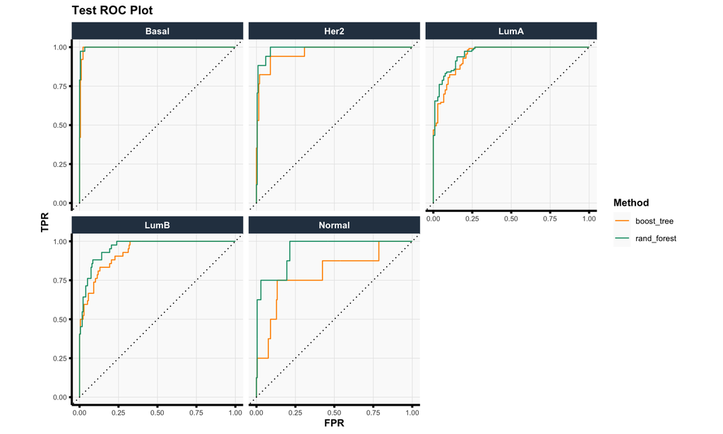

### PR Plot

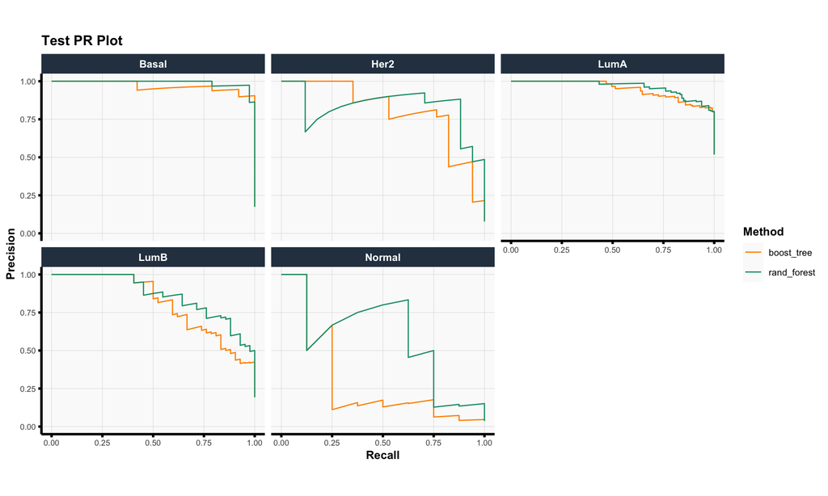

# 5 Post hoc analysis

Move beyond the global prediction accuracy metrics and dive deeper into individual-level predictions for the validation and/or test set, i.e., provide a more “local” analysis.

Examine any points that had poor predictions.

> As mentioned in the stability analysis, check for any commonalities among perturbations, or specific observations, that resulted in poor accuracy metrics across procedures.

Examine differences between prediction methods.

> Are there certain methods that may not be overall the most accurate, but outperform others on the more “challenging” validation/test observations? Conversely, are some procedures very effective across the majority of observations, but some outlying behavior effects overall results?

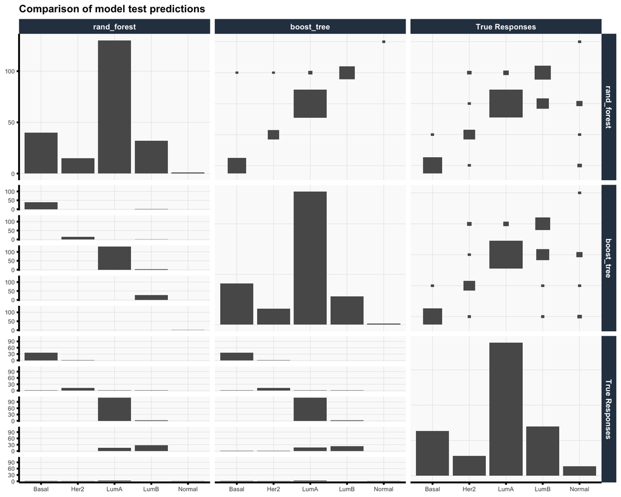

```r
pred_results_final %>%
  dplyr::mutate(.id = rep(1:nrow(Xtest), length.out = dplyr::n())) %>%
  tidyr::pivot_wider(id_cols = .id,
                     names_from = "method", values_from = "predictions") %>%
  dplyr::mutate(`True Responses` = ytest) %>%
  plot_pairs(columns = 2:(length(unique(pred_results_final$method)) + 2),
             title = "Comparison of model test predictions")
```

# 6 Conclusions

Reiterate main findings, note any caveats, and clearly translate findings/analysis back to the domain problem context.